# R Notebook

```r
library(tigerstats)
library(tidyverse)
library(readxl)
library(ggplot2)
```

# Exercicio 1

Exercício 1 (Bruni, Adriano Leal, 2005, p.87): Os dados seguintes apresentam as produções diárias em unidades da fábrica de roupas na moda ltda. Com base nos números fornecidos, determine os quartis.

```r
Roupas <- c(10,10,11,11,12,15,15,16,19,22,22,25,27,28,30,30,32,35,36,37,37,38,40,41,45)
```

Para determinar os quartis é utilizado a função summary(), a qual calcula o valor minimo, primeiro quartil, mediana, média, terceiro quartil e o valor máximo:

```r
summary(Roupas)
```

```
   Min. 1st Qu.  Median    Mean 3rd Qu.    Max.
  10.00   15.00   27.00   25.76   36.00   45.00
```

valor minimo:10 primeiro quartil:15 mediana:27 média:25.76 terceiro quartil: 36 valor máximo: 45

# Exercicio 2

Exercício 2 (Bruni, Adriano Leal, 2005, p.283): Considere o exemplo fictício da Ceres Fruticultura Irrigada Ltda. A empresa coletou dados referentes ao volume de chuvas nos últimos seis anos e a produtividade média por hectare em seis culturas diferentes: manga, abacate, ameixa, goiaba e acerola. Apresente o histograma de dispersão e suas principais informações estatísticas.

Primeiramente precisamos extrair os dados do exercicios, os quais estão no excel

```r
Ex2 <- read_excel("C:/Users/LucasZan/Desktop/Ex2.xlsx")
## View(Ex2)
```

Novamente pra começar buscamos os valores estatísticos básicos utilizando o summary(), o que vai nos demonstrar os falores de quartils, mediana e média

```r
summary(Ex2)
```

```
     Ano i          chuvas         manga        abacate
 Min.   :1.00   Min.   :10.0   Min.   : 70   Min.   : 86.00
 1st Qu.:2.25   1st Qu.:18.5   1st Qu.: 87   1st Qu.: 98.25
 Median :3.50   Median :22.5   Median : 95   Median :118.50
 Mean   :3.50   Mean   :25.0   Mean   :100   Mean   :125.17
 3rd Qu.:4.75   3rd Qu.:32.5   3rd Qu.:115   3rd Qu.:142.50
 Max.   :6.00   Max.   :42.0   Max.   :134   Max.   :186.00
     ameixa          goiaba         acerola
 Min.   :32.00   Min.   :15.00   Min.   :29.00
 1st Qu.:37.50   1st Qu.:15.00   1st Qu.:33.75
 Median :39.25   Median :16.65   Median :38.75
 Mean   :38.83   Mean   :18.88   Mean   :37.50
 3rd Qu.:39.50   3rd Qu.:23.32   3rd Qu.:40.75
 Max.   :46.00   Max.   :25.00   Max.   :45.00
```

Gerando os Histogramas

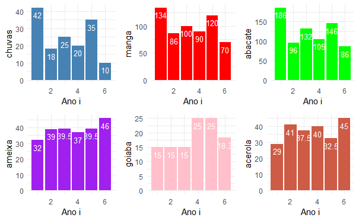

```r
library(cowplot)
plot1<- ggplot(data=Ex2, aes(x=`Ano i`, y=chuvas)) +
  geom_bar(stat="identity", fill="steelblue") +
  geom_text(aes(label=chuvas), vjust=1.6, color="white", size=3.5)+
  theme_minimal()

plot2<- ggplot(data=Ex2, aes(x=`Ano i`, y=manga)) +
  geom_bar(stat="identity", fill="red") +
  geom_text(aes(label=manga), vjust=1.6, color="white", size=3.5)+
  theme_minimal()

plot3<- ggplot(data=Ex2, aes(x=`Ano i`, y=abacate)) +
  geom_bar(stat="identity", fill="green") +
  geom_text(aes(label=abacate), vjust=1.6, color="white", size=3.5)+
  theme_minimal()

plot4<- ggplot(data=Ex2, aes(x=`Ano i`, y=ameixa)) +
  geom_bar(stat="identity", fill="purple") +
  geom_text(aes(label=ameixa), vjust=1.6, color="white", size=3.5)+
  theme_minimal()

plot5<- ggplot(data=Ex2, aes(x=`Ano i`, y=goiaba)) +
  geom_bar(stat="identity", fill="pink") +
  geom_text(aes(label=goiaba), vjust=1.6, color="white", size=3.5)+
  theme_minimal()

plot6<- ggplot(data=Ex2, aes(x=`Ano i`, y=acerola)) +
  geom_bar(stat="identity", fill="coral3") +
  geom_text(aes(label=acerola), vjust=1.6, color="white", size=3.5)+
  theme_minimal()

plot_grid(plot1, plot2, plot3, plot4, plot5, plot6)
```

Para calcular a regressão é utilizado a função lm, verificando a relação entre a chuva e as médias por hectare das 5 culturas

```r
reg1 <- lm(manga ~ chuvas, data = Ex2)
summary(reg1)
```

```
essentially perfect fit: summary may be unreliable
```

```
Call:
lm(formula = manga ~ chuvas, data = Ex2)

Residuals:
         1          2          3          4          5          6
 5.776e-15  7.702e-15 -2.876e-15 -3.100e-16 -8.008e-15 -2.283e-15

Coefficients:
             Estimate Std. Error   t value Pr(>|t|)
(Intercept) 5.000e+01  6.767e-15 7.388e+15   <2e-16 ***
chuvas      2.000e+00  2.488e-16 8.038e+15   <2e-16 ***
---
Signif. codes:  0 ‘***’ 0.001 ‘**’ 0.01 ‘*’ 0.05 ‘.’ 0.1 ‘ ’ 1

Residual standard error: 6.527e-15 on 4 degrees of freedom
Multiple R-squared:      1, Adjusted R-squared:      1
F-statistic: 6.46e+31 on 1 and 4 DF,  p-value: < 2.2e-16
```

```r
cor(Ex2$chuvas, Ex2$manga)
```

```
[1] 1
```

Tendo um R² igual a 1 significa que a manga é totalmente relativa a chuva, sendo assim é possivel demonstar pelo gráfico de acordo com o aumento da chuva também aumenta a quantidade média de manga por hectar e a linha da regressão linear passa por todos os pontos.

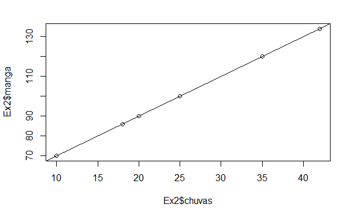

```r
plot(Ex2$chuvas, Ex2$manga)
abline(reg1)
```

```r
reg2 <- lm(abacate ~ chuvas, data = Ex2)
summary(reg2)
```

```
Call:
lm(formula = abacate ~ chuvas, data = Ex2)

Residuals:
      1       2       3       4       5       6
  8.079  -7.444   6.833  -4.651 -10.199   7.381

Coefficients:
            Estimate Std. Error t value Pr(>|t|)
(Intercept)  47.5867     9.6644   4.924 0.007907 **
chuvas        3.1032     0.3554   8.733 0.000947 ***
---
Signif. codes:  0 ‘***’ 0.001 ‘**’ 0.01 ‘*’ 0.05 ‘.’ 0.1 ‘ ’ 1

Residual standard error: 9.321 on 4 degrees of freedom
Multiple R-squared:  0.9502,    Adjusted R-squared:  0.9377
F-statistic: 76.26 on 1 and 4 DF,  p-value: 0.0009473
```

```r
cor(Ex2$chuvas, Ex2$abacate)
```

```
[1] 0.974763
```

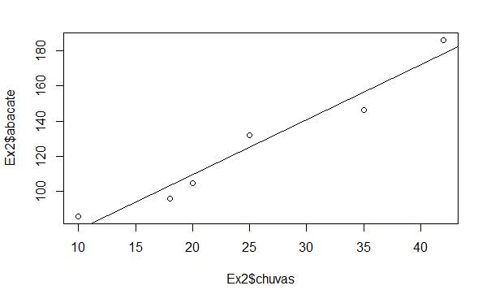

```r
plot(Ex2$chuvas, Ex2$abacate)
abline(reg2)
```

```r
reg3 <- lm(ameixa ~ chuvas, data = Ex2)
summary(reg3)
```

```
Call:
lm(formula = ameixa ~ chuvas, data = Ex2)

Residuals:
      1       2       3       4       5       6
-1.6691 -1.9598  0.6667 -3.3522  3.7045  2.6100

Coefficients:
            Estimate Std. Error t value Pr(>|t|)
(Intercept)  46.4278     3.2311  14.369 0.000136 ***
chuvas       -0.3038     0.1188  -2.557 0.062841 .
---
Signif. codes:  0 ‘***’ 0.001 ‘**’ 0.01 ‘*’ 0.05 ‘.’ 0.1 ‘ ’ 1

Residual standard error: 3.116 on 4 degrees of freedom
Multiple R-squared:  0.6204,    Adjusted R-squared:  0.5255
F-statistic: 6.538 on 1 and 4 DF,  p-value: 0.06284
```

```r
cor(Ex2$chuvas, Ex2$ameixa)
```

```
[1] -0.7876686
```

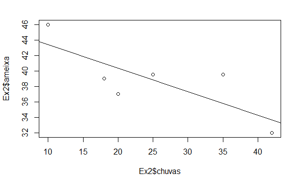

```r
plot(Ex2$chuvas, Ex2$ameixa)
abline(reg3)
```

```r
reg4 <- lm(goiaba ~ chuvas, data = Ex2)
summary(reg4)
```

```
Call:
lm(formula = goiaba ~ chuvas, data = Ex2)

Residuals:
      1       2       3       4       5       6
-3.8957 -3.8782 -3.8833  6.1203  6.1094 -0.5724

Coefficients:
             Estimate Std. Error t value Pr(>|t|)
(Intercept) 1.887e+01  5.689e+00   3.316   0.0295 *
chuvas      7.267e-04  2.092e-01   0.003   0.9974
---
Signif. codes:  0 ‘***’ 0.001 ‘**’ 0.01 ‘*’ 0.05 ‘.’ 0.1 ‘ ’ 1

Residual standard error: 5.487 on 4 degrees of freedom
Multiple R-squared:  3.018e-06, Adjusted R-squared:  -0.25
F-statistic: 1.207e-05 on 1 and 4 DF,  p-value: 0.9974
```

```r
cor(Ex2$chuvas, Ex2$goiaba)
```

```
[1] 0.001737191
```

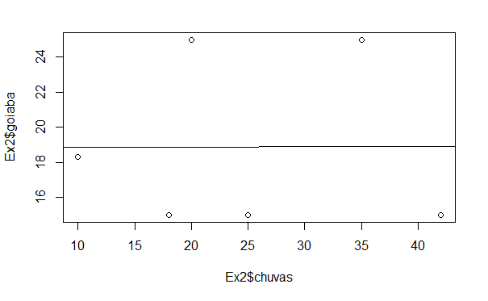

```r
plot(Ex2$chuvas, Ex2$goiaba)
abline(reg4)
```

```r
reg5 <- lm(acerola ~ chuvas, data = Ex2)
summary(reg5)
```

```
essentially perfect fit: summary may be unreliable
```

```
Call:
lm(formula = acerola ~ chuvas, data = Ex2)

Residuals:
         1          2          3          4          5          6
 5.854e-15 -1.122e-15 -2.220e-15 -8.127e-16 -5.478e-15  3.778e-15

Coefficients:
              Estimate Std. Error    t value Pr(>|t|)
(Intercept)  5.000e+01  4.791e-15  1.044e+16   <2e-16 ***
chuvas      -5.000e-01  1.762e-16 -2.838e+15   <2e-16 ***
---
Signif. codes:  0 ‘***’ 0.001 ‘**’ 0.01 ‘*’ 0.05 ‘.’ 0.1 ‘ ’ 1

Residual standard error: 4.62e-15 on 4 degrees of freedom
Multiple R-squared:      1, Adjusted R-squared:      1
F-statistic: 8.057e+30 on 1 and 4 DF,  p-value: < 2.2e-16
```

```r
cor(Ex2$chuvas, Ex2$acerola)
```

```
[1] -1
```

Tendo um R² igual a 1 significa que a acerola é totalmente relativa a chuva, mas com a sua correlação igual a -1 demontra q a relação é de que com o aumento da chuva diminui a quantidade média de acerola por hectar e a linha da regressão linear passa por todos os pontos.

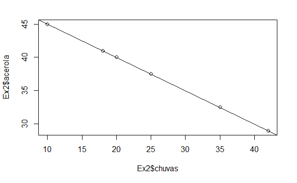

```r
plot(Ex2$chuvas, Ex2$acerola)
abline(reg5)
```

# Exercicio 3

Exercício 3 (Bruni, Adriano Leal, 2005, p.278): Uma rede de lojas de confecções que coletou uma amostra de dados passados referentes a seus gastos com publicidade ($mil) e seu volume de vendas ($mil). Os dados são: determine o gráfico de dispersão e as principais estatísticas descritivas para posterior inferências.

```r
ex3 <- data.frame("GP" = c(3,4,4.8,5.9,8,8.5,10,12,14), "Vendas"= c(7,14,14.3,14.7,15,15.4,19,28,32))
```

Principais estatísticas descritivas

```r
summary(ex3)
```

```
       GP           Vendas
 Min.   : 3.0   Min.   : 7.00
 1st Qu.: 4.8   1st Qu.:14.30
 Median : 8.0   Median :15.00
 Mean   : 7.8   Mean   :17.71
 3rd Qu.:10.0   3rd Qu.:19.00
 Max.   :14.0   Max.   :32.00
```

```r
regex3 <- lm(Vendas ~ GP, data = ex3)
summary(regex3)
```

```
Call:
lm(formula = Vendas ~ GP, data = ex3)

Residuals:
    Min      1Q  Median      3Q     Max
-3.6538 -2.9310  0.6334  2.3433  3.5778

Coefficients:
            Estimate Std. Error t value Pr(>|t|)
(Intercept)   2.7496     2.4347   1.129 0.295978
GP            1.9181     0.2845   6.742 0.000267 ***
---
Signif. codes:  0 ‘***’ 0.001 ‘**’ 0.01 ‘*’ 0.05 ‘.’ 0.1 ‘ ’ 1

Residual standard error: 3.005 on 7 degrees of freedom
Multiple R-squared:  0.8665,    Adjusted R-squared:  0.8475
F-statistic: 45.45 on 1 and 7 DF,  p-value: 0.000267
```

```r
cor(ex3$GP, ex3$Vendas)
```

```
[1] 0.9308854
```

Corelação entre valor de 0.93 e possitiva, R² de 0.8665

Gráfico de dispersão com reta de regrassão

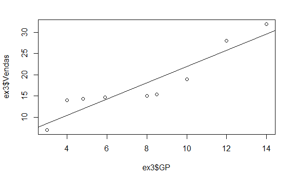

```r
plot(ex3$GP, ex3$Vendas)
abline(regex3)
```

#Exercicio 4

Exercício 4 (Fávero, base de dados, 2018):

```r
ex4 <- read_excel("C:/Users/LucasZan/Downloads/2.xlsx")
#View(ex4)
```

```r
summary(ex4)
```

```
  Estudante
 Length:100
 Class :character
 Mode  :character



 Chegou Atrasado à Escola (Dummy Sim = 1;  Não = 0) (Y)
 Min.   :0.00
 1st Qu.:0.00
 Median :1.00
 Mean   :0.59
 3rd Qu.:1.00
 Max.   :1.00
 Distância (km) (X1) Quantidade Semáforos   (X2)
 Min.   : 1.00       Min.   : 5.00
 1st Qu.:12.00       1st Qu.:10.00
 Median :13.35       Median :10.00
 Mean   :14.07       Mean   :10.21
 3rd Qu.:16.12       3rd Qu.:10.00
 Max.   :29.00       Max.   :18.00
```

Dividindo os atrasados dos nao atrasdos

```r
atrasados <- ex4[ex4$`Chegou Atrasado à Escola (Dummy Sim = 1;  Não = 0) (Y)`  == 1,]
natrasados <- ex4[ex4$`Chegou Atrasado à Escola (Dummy Sim = 1;  Não = 0) (Y)` ==0,]
prop.table(table(ex4$`Chegou Atrasado à Escola (Dummy Sim = 1;  Não = 0) (Y)`)) *100
```

```
 0  1
41 59
```

```r
C <- list(atrasados,natrasados)
```

59% dos alunos chegaram atrasados

```r
summary(atrasados)
```

```
  Estudante
 Length:59
 Class :character
 Mode  :character



 Chegou Atrasado à Escola (Dummy Sim = 1;  Não = 0) (Y)
 Min.   :1
 1st Qu.:1
 Median :1
 Mean   :1
 3rd Qu.:1
 Max.   :1
 Distância (km) (X1) Quantidade Semáforos   (X2)
 Min.   : 1.00       Min.   :10.00
 1st Qu.:12.00       1st Qu.:10.00
 Median :14.20       Median :10.00
 Mean   :14.57       Mean   :10.71
 3rd Qu.:17.00       3rd Qu.:11.00
 Max.   :29.00       Max.   :18.00
```

distancia minima 1 media 14.57 max 29

```r
summary(natrasados)
```

```
  Estudante
 Length:41
 Class :character
 Mode  :character



 Chegou Atrasado à Escola (Dummy Sim = 1;  Não = 0) (Y)
 Min.   :0
 1st Qu.:0
 Median :0
 Mean   :0
 3rd Qu.:0
 Max.   :0
 Distância (km) (X1) Quantidade Semáforos   (X2)
 Min.   : 9.50       Min.   : 5.000
 1st Qu.:12.00       1st Qu.:10.000
 Median :13.00       Median :10.000
 Mean   :13.35       Mean   : 9.488
 3rd Qu.:14.00       3rd Qu.:10.000
 Max.   :23.50       Max.   :11.000
```

minima 9.5 media 13.35 max 23.5

```r
cor(ex4$`Chegou Atrasado à Escola (Dummy Sim = 1;  Não = 0) (Y)`,ex4$`Distância (km) (X1)`)
```

```
[1] 0.1391824
```

```r
regex41 <- lm(`Chegou Atrasado à Escola (Dummy Sim = 1;  Não = 0) (Y)` ~ `Distância (km) (X1)`, data = ex4)
summary(regex41)
```

```
Call:
lm(formula = `Chegou Atrasado à Escola (Dummy Sim = 1;  Não = 0) (Y)` ~
    `Distância (km) (X1)`, data = ex4)

Residuals:
    Min      1Q  Median      3Q     Max
-0.7398 -0.5583  0.3317  0.4247  0.6177

Coefficients:
                      Estimate Std. Error t value Pr(>|t|)
(Intercept)            0.36640    0.16807   2.180   0.0316 *
`Distância (km) (X1)`  0.01589    0.01142   1.391   0.1673
---
Signif. codes:  0 ‘***’ 0.001 ‘**’ 0.01 ‘*’ 0.05 ‘.’ 0.1 ‘ ’ 1

Residual standard error: 0.492 on 98 degrees of freedom
Multiple R-squared:  0.01937,   Adjusted R-squared:  0.009365
F-statistic: 1.936 on 1 and 98 DF,  p-value: 0.1673
```

existe uma correlação entre a distancia e o atraso, mas ela é MUITO baixa (0.139) e um R² de somente 0.0193

```r
cor(ex4$`Chegou Atrasado à Escola (Dummy Sim = 1;  Não = 0) (Y)`,ex4$`Quantidade Semáforos   (X2)`)
```

```
[1] 0.3833829
```

```r
regex42 <- lm(`Chegou Atrasado à Escola (Dummy Sim = 1;  Não = 0) (Y)` ~ `Quantidade Semáforos   (X2)`, data = ex4)
summary(regex42)
```

```
Call:
lm(formula = `Chegou Atrasado à Escola (Dummy Sim = 1;  Não = 0) (Y)` ~
    `Quantidade Semáforos   (X2)`, data = ex4)

Residuals:
    Min      1Q  Median      3Q     Max
-0.6849 -0.5648  0.3151  0.4352  0.4352

Coefficients:
                              Estimate Std. Error t value Pr(>|t|)
(Intercept)                   -0.63599    0.30186  -2.107   0.0377 *
`Quantidade Semáforos   (X2)`  0.12008    0.02922   4.109 8.24e-05 ***
---
Signif. codes:  0 ‘***’ 0.001 ‘**’ 0.01 ‘*’ 0.05 ‘.’ 0.1 ‘ ’ 1

Residual standard error: 0.4589 on 98 degrees of freedom
Multiple R-squared:  0.147, Adjusted R-squared:  0.1383
F-statistic: 16.89 on 1 and 98 DF,  p-value: 8.245e-05
```

existe uma correlação entre a quantidade de semafors e o atraso, mas ela é MUITO baixa (0.383) e um R² de somente 0.147

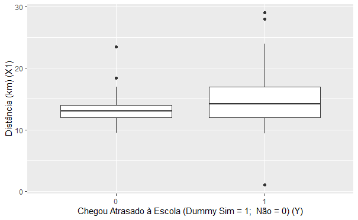

```r
ex4$`Chegou Atrasado à Escola (Dummy Sim = 1;  Não = 0) (Y)` <- as.factor(ex4$`Chegou Atrasado à Escola (Dummy Sim = 1;  Não = 0) (Y)`)
plotx <- ggplot(ex4, aes(y = `Distância (km) (X1)`, x = `Chegou Atrasado à Escola (Dummy Sim = 1;  Não = 0) (Y)`)) +
                  geom_boxplot()
plotx
```

```r
#ploty <- ggplot(natrasados, aes(y = `Distância (km) (X1)`,x = 0)) +
#                  geom_boxplot()
#plot_grid(plotx,ploty)
```

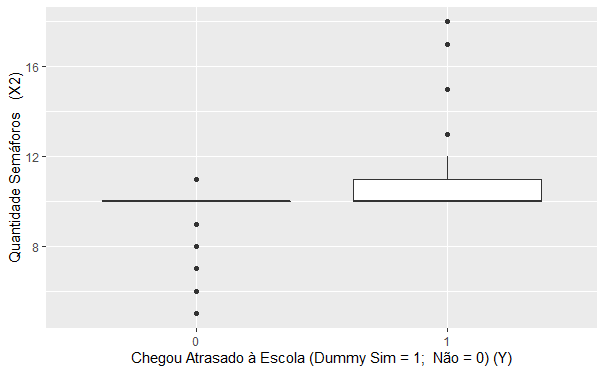

```r
ploty <- ggplot(ex4, aes(y = `Quantidade Semáforos   (X2)`, x = `Chegou Atrasado à Escola (Dummy Sim = 1;  Não = 0) (Y)`)) +
                  geom_boxplot()
ploty
```

pelos box plots é possivel ver que os alunos que nao se atrasaram tem 10 sinaleiras ou menos (com uma exeção) onde todos que se atrasaram pegam 10 sinaleiras ou mais

#Exercicio 5 Exercício 5 (Larson e Farber, 2010, p.412): A idade (em anos) de sete crianças e o número de palavras que compõem o vocabulário. Represente o gráfico de dispersão e a reta de regressão. Explique os resultados.

```r
ex5 <- data.frame("Idade" = c(3,4,4,5,6,2,3), "TVocabulario"= c(1100,1300,1500,2100,2600,460,1200))
```

```r
regex5 <- lm(TVocabulario ~ Idade, data = ex5)
summary(regex5)
```

```
Call:
lm(formula = TVocabulario ~ Idade, data = ex5)

Residuals:
      1       2       3       4       5       6       7
  72.11 -238.68  -38.68   50.53   39.74  -57.11  172.11

Coefficients:
            Estimate Std. Error t value Pr(>|t|)
(Intercept)  -504.47     174.55   -2.89   0.0342 *
Idade         510.79      43.07   11.86  7.5e-05 ***
---
Signif. codes:  0 ‘***’ 0.001 ‘**’ 0.01 ‘*’ 0.05 ‘.’ 0.1 ‘ ’ 1

Residual standard error: 141.9 on 5 degrees of freedom
Multiple R-squared:  0.9657,    Adjusted R-squared:  0.9588
F-statistic: 140.7 on 1 and 5 DF,  p-value: 7.503e-05
```

```r
cor(ex5$Idade, ex5$TVocabulario)
```

```
[1] 0.9826892
```

Correlação de 0.982 entre a Idade e o Tamanho do Vocabulário de forma positiva e R² igual a 0.9657

Grafico de dispersão com a Reta de Regressão demontrando a correlação possiva

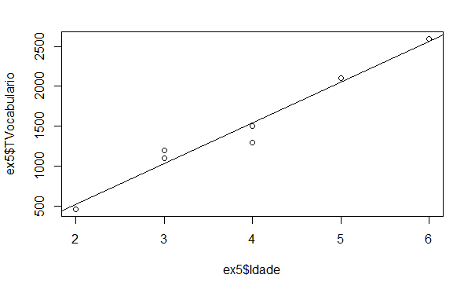

```r
plot(ex5$Idade, ex5$TVocabulario)
abline(regex5)
```

#Exercicio 6

Exercício 6 (Larson e Farber, 2010, p.412): O número de horas que 13 alunos passaram estudando para um teste e a pontuação nele. Represente o gráfico de dispersão e a reta de regressão. Explique os resultados.

```r
ex6 <- data.frame("Horas_estudando" = c(0,1,2,4,4,5,5,5,6,6,7,7,8), "Pontuacao_teste" = c(40,41,51,48,64,69,73,75,68,93,84,90,95))
```

```r
regex6 <- lm(Horas_estudando ~ Pontuacao_teste, data = ex6)
summary(regex6)
```

```
Call:
lm(formula = Horas_estudando ~ Pontuacao_teste, data = ex6)

Residuals:
    Min      1Q  Median      3Q     Max
-1.4487 -0.4257 -0.1012  0.3312  1.7635

Coefficients:
                Estimate Std. Error t value Pr(>|t|)
(Intercept)      -3.3232     1.0357  -3.209  0.00833 **
Pontuacao_teste   0.1158     0.0146   7.935 7.06e-06 ***
---
Signif. codes:  0 ‘***’ 0.001 ‘**’ 0.01 ‘*’ 0.05 ‘.’ 0.1 ‘ ’ 1

Residual standard error: 0.9664 on 11 degrees of freedom
Multiple R-squared:  0.8513,    Adjusted R-squared:  0.8378
F-statistic: 62.97 on 1 and 11 DF,  p-value: 7.058e-06
```

```r
cor(ex6$Pontuacao_teste, ex6$Horas_estudando)
```

```
[1] 0.9226499
```

Correlação de 0.922 positiva e R² de 0.851

Grafico de dispersão com a Reta de Regressão demontrando a correlação possiva

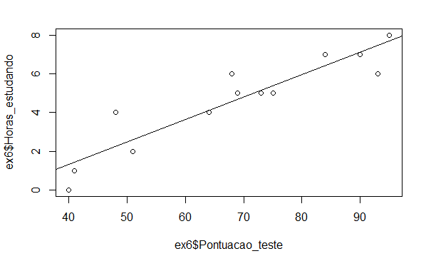

```r
plot(ex6$Pontuacao_teste, ex6$Horas_estudando)
abline(regex6)
```

#Exercicio 7 Exercício 7 (Larson e Farber, 2010, p.413): Usando o diagrama de dispersão dos dados sobre os salários dos administradores apresentados, que tipo de correlação, se é que há alguma, você acha que os dados têm? Aproveite, calcule a regressão linear simples e explique os resultados. Escreva uma paragrafo descrevendo a relação de causa e efeito entre a idade e o salário anual do administrador.

```r
ex7 <- read_excel("C:/Users/LucasZan/Downloads/7.xlsx")
```

```r
regex7 <- lm(`Salário anual (em mil reais)` ~ `Idade (em anos)`, data = ex7)
summary(regex7)
```

```
Call:
lm(formula = `Salário anual (em mil reais)` ~ `Idade (em anos)`,
    data = ex7)

Residuals:
     Min       1Q   Median       3Q      Max
-10.0561  -0.9197   0.4886   2.3432   2.8912

Coefficients:
                  Estimate Std. Error t value Pr(>|t|)
(Intercept)       43.98941    2.38717   18.43 3.94e-13 ***
`Idade (em anos)`  0.55749    0.04821   11.56 9.14e-10 ***
---
Signif. codes:  0 ‘***’ 0.001 ‘**’ 0.01 ‘*’ 0.05 ‘.’ 0.1 ‘ ’ 1

Residual standard error: 3.261 on 18 degrees of freedom
Multiple R-squared:  0.8814,    Adjusted R-squared:  0.8748
F-statistic: 133.7 on 1 and 18 DF,  p-value: 9.135e-10
```

```r
cor(ex7$`Idade (em anos)`, ex7$`Salário anual (em mil reais)`)
```

```
[1] 0.9388106
```

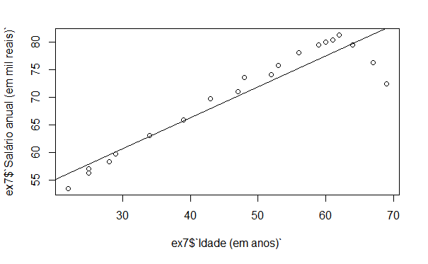

```r
plot(ex7$`Idade (em anos)`, ex7$`Salário anual (em mil reais)`)
abline(regex7)
```

#Exercicio 8